# EVDS HW1 yeni

Ibrahim Aykut

02 05 2021

## Libraries

```r
library(EVDS)
library(tidyverse)
library(lubridate)
library(zoo)
```

### NOTE

When I first began to work on dataset, ı was able to get data from EVDS by using EVDS package. But as you know, a few days ago API began to not work. I had already got some data and had saved the graphs. So, what I did to complete my homework, to create a new markdown file, add graphs as pictures, put hastagh(#) sign to R codes to prevent them to work(otherwise, I get error due to evds problem). And I added the last part of my homework.

## Data Retrieval from EVDS

I got number of house sold each month, monthly interest rate, currency rate and monthly house price index as of 01-01-2015 from EVDS.

```r
set_evds_key("yCmlEOOcJn")
#df <- get_series(series = c( "TP.MT210AGS.TRY.MT06","TP.AKONUTSAT1.TOPLAM","TP.DK.USD.A.YTL","TP.HKFE01"),start_date = "01-01-2015", end_date = "28-02-2021")
```

## Data Manipulation

Firstly, I edited the date format by using lubridate package. So, new date format can be used on time series. Then, I converted other variables’ data type from chr to num. And I changed their names to more understandable names. Afterward, I added all these changes to the current data frame as new variables.

```r
#df1 <- df$items %>%
#  select(-UNIXTIME) %>%
#  na.omit() %>%
#  mutate(Date = ym(Tarih),Mevduat_Faiz_Oranı=as.double(TP_MT210AGS_TRY_MT06), Konut_Satis=as.double(TP_AKONUTSAT1_TOPLAM),USD_Kur=as.double(TP_DK_USD_A_YTL),Konut_Fiyat_Endeksi=as.double(TP_HKFE01))
```

## Data Summary

```r
#str(df1)
```

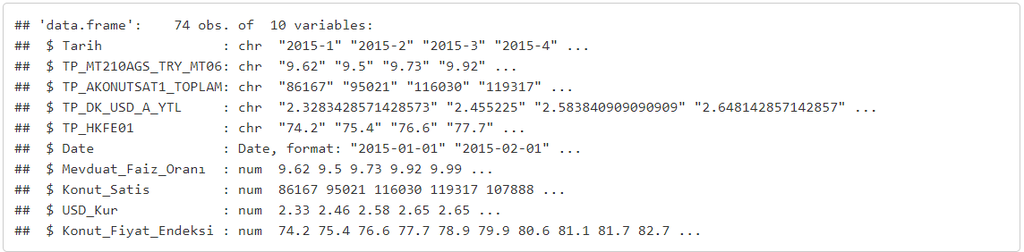

## Plot of Number of House Sold

When we look at the number of houses sold plot, it seems there is a fluctuation throughout the years. This shows the data has seasonality. It can be seen an increase on November and December while decrease in the summer season. The Only exception is 2020. There is a highly increasing trend in the summer of 2020. The reason might be the pandemic. From May 2020 to July 2020, the number of house sales increased almost more than 4 times. When it is compared this graph with the house price index and USD currency graphs, we can’t see any similarity.

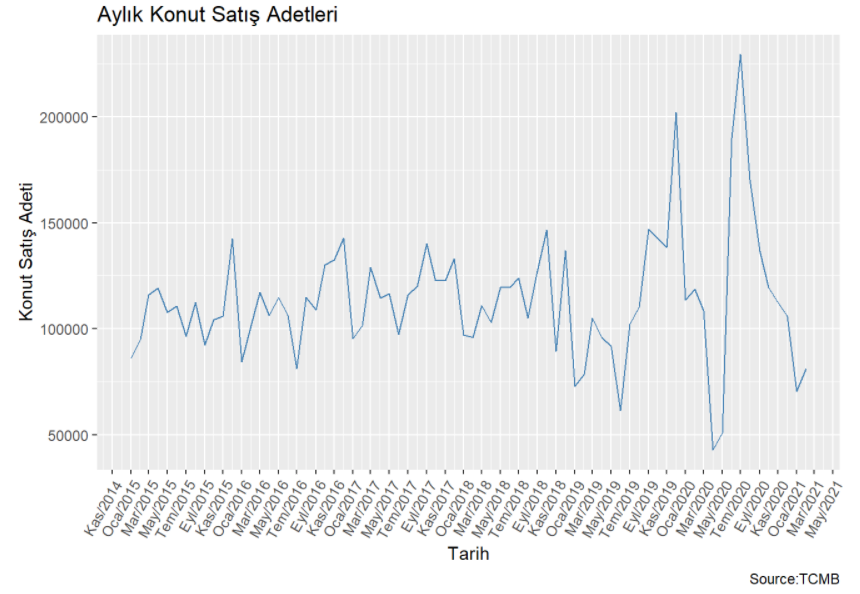

```r
#ggplot(df1, aes(x=Date,y=Konut_Satis)) +
#  scale_x_date(date_breaks = "2 month", date_labels = "%b/%Y") + theme(axis.text.x=element_text(angle=60, hjust=1)) +
 # geom_line(color="steelblue") +
  #labs(title="Aylık Konut Satış Adetleri", x="Tarih",y="Konut Satış Adeti",caption = "Source:TCMB")
```

## Plot of House Price Index

We see increasing trend for house price index.

[figure not shown]

```r
#ggplot(df1, aes(x=Date,y=Konut_Fiyat_Endeksi)) +
#  scale_x_date(date_breaks = "2 month", date_labels = "%b/%Y") + theme(axis.text.x=element_text(angle=60, hjust=1)) +
 # geom_line(color="steelblue") +
  #labs(title="Aylık Konut Satış Adetleri", x="Tarih",y="Konut Satış Adeti",caption = "Source:TCMB")
```

## Plot of USD Currency

USD currency has increased during the years. The trend is similar to house price index. It seems there is a correlation between two variables.

[figure not shown]

```r
#ggplot(df1, aes(x=Date,y=USD_Kur)) +
#  scale_x_date(date_breaks = "2 month", date_labels = "%b/%Y") + theme(axis.text.x=element_text(angle=60, hjust=1)) +
 # geom_line(color="steelblue") +
  #labs(title="Aylık Konut Satış Adetleri", x="Tarih",y="Konut Satış Adeti",caption = "Source:TCMB")
```

## Plot of “Emlak” search on Google Trends

When I search emlak on Google Trends, it seems that the search trend is somehow similar to plot of number of house sold, but not the same. We can see similarities especially from March 2020 to July 2020. Both graphs have a quite high increasing trend.

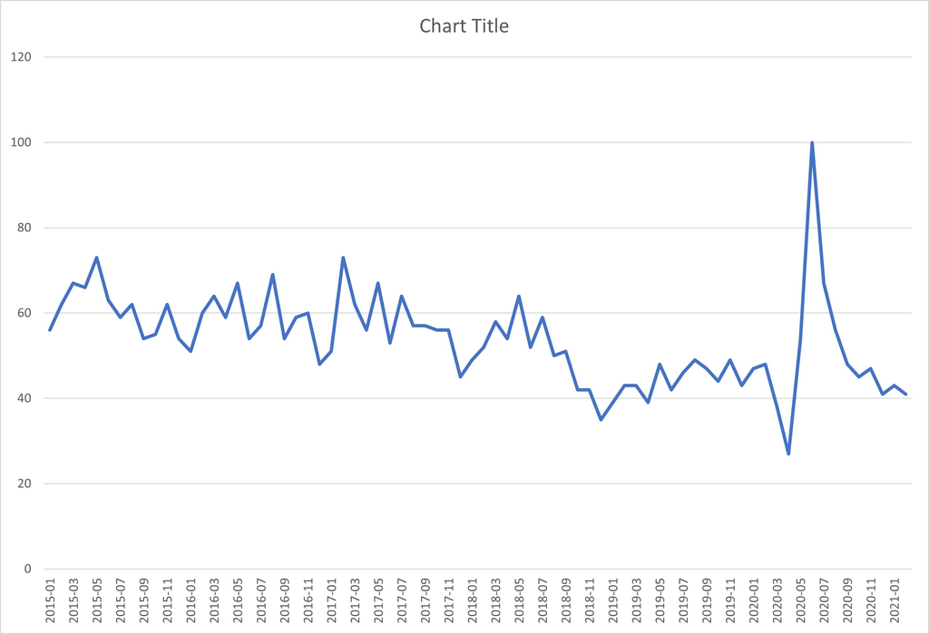